# Foundation Shade Inclusivity Analysis

How evenly do 10 beauty brands spread their foundation shades from light to deep?

Ella Rwenzo

Data collected September 28, 2026

```r
# Packages used (all free on CRAN):
#   install.packages(c("dplyr", "tidyr", "readr", "stringr", "forcats",
#                      "ggplot2", "farver", "scales", "knitr", "rmarkdown"))
library(dplyr)    # data cleaning
library(tidyr)    # reshaping tables
library(readr)    # reading and writing CSV files
library(stringr)  # text cleaning
library(forcats)  # ordering categories in charts
library(ggplot2)  # charts
library(farver)   # color conversion (used to double-check my own formula)
library(scales)   # percent labels

dir.create("data/clean", showWarnings = FALSE, recursive = TRUE)
dir.create("output/charts", showWarnings = FALSE, recursive = TRUE)
dir.create("output/tables", showWarnings = FALSE, recursive = TRUE)
```

# 1 The question

**When a brand makes a foundation in many shades, are those shades spread evenly from light to deep, or are they bunched up at the light end?**

I break that into four smaller questions:

1. **Reach.** How light is each brand’s lightest shade, and how deep is its deepest?
2. **Balance.** What share of the shades sit in the deeper half of the light-to-deep scale?
3. **Spacing.** Are deep shades as close together as light shades? Close spacing means a customer is more likely to find a near-exact match.
4. **Size vs. balance.** Do products with more shades also offer a larger share of deep shades?

I did not assume any brand was or wasn’t inclusive. Every conclusion below comes from the data.

# 2 Why it matters

Foundation is supposed to match your skin. If a range has 40 shades but 30 of them are light, a person with deep skin effectively has 10 choices, and those 10 are spread thin, so the “closest” shade may still be a poor match. A shade count on the box does not show that. This project measures it.

# 3 Data sources

- **Brands (10):** e.l.f., Maybelline, Huda Beauty, Charlotte Tilbury, Hourglass, L’Oréal Paris, Laura Mercier, NYX Professional Makeup, Rare Beauty, Makeup by Mario.
- **Where:** each brand’s **official US website**, collected on **September 28, 2026**.
- **Which products:** every foundation, skin tint, CC cream and liquid “glow filter” listed in the Foundation section of the brand’s site. I left out powders, primers, concealers, brushes, minis (same shades as the full size) and one-shade products.
- **Every shade counts,** including shades that were sold out that day, because the question is about which shades a brand *makes*.

```r
shades_raw <- read_csv("data/raw/shades_raw.csv", col_types = cols(.default = col_character()))
products   <- read_csv("data/raw/products.csv",   col_types = cols(.default = col_character()))

products %>%
  count(brand, included, name = "products") %>%
  pivot_wider(names_from = included, values_from = products, values_fill = 0,
              names_prefix = "included_") %>%
  knitr::kable(caption = "Products collected per brand")
```

Products collected per brand

| brand | included_yes | included_no |
| --- | --- | --- |
| Charlotte Tilbury | 4 | 0 |
| Hourglass | 4 | 0 |
| Huda Beauty | 1 | 1 |
| L’Oreal Paris | 11 | 0 |
| Laura Mercier | 6 | 0 |
| Makeup by Mario | 2 | 0 |
| Maybelline | 8 | 0 |
| NYX Professional Makeup | 3 | 1 |
| Rare Beauty | 2 | 1 |
| e.l.f. | 5 | 0 |

Three products were dropped because the brand is clearing them out. Ten percent or fewer of their shades could be bought on collection day:

```r
products %>%
  filter(included == "no") %>%
  select(brand, product, shades_collected, exclusion_reason) %>%
  knitr::kable()
```

| brand | product | shades_collected | exclusion_reason |
| --- | --- | --- | --- |
| Huda Beauty | #FauxFilter Luminous Matte Foundation | 4 | Clearance: 1 of 39 shades in stock; page shows only 4 leftover shades |
| NYX Professional Makeup | Can’t Stop Won’t Stop Full Coverage Foundation | 23 | Clearance: 0 of 23 listed shades in stock |
| Rare Beauty | Positive Light Tinted Moisturizer SPF 20 | 24 | Clearance: 2 of 24 shades in stock |

# 4 How the swatch colors were collected

Every product page shows a small colored circle or square (a *swatch*) for each shade. Each row of the dataset is one of those swatches. Brands draw swatches in one of two ways, and I read each kind the most direct way:

| Swatch type | Brands | How the color was read |
| --- | --- | --- |
| **Color code** | e.l.f., Maybelline, Huda Beauty, Hourglass, L’Oréal Paris, Laura Mercier, NYX | The page paints the swatch with a color code (for example `#BA8656`). I recorded that code exactly. |
| **Image** | Charlotte Tilbury, Rare Beauty, Makeup by Mario | The swatch is a small photo of the product. A script read the middle half of the photo, ignored the brightest 25% and darkest 25% of pixels (shine and shadow), and averaged the rest into one color. |

So the pipeline is: **product page swatch → HEX color → R, G, B → lightness (L*) → analysis.**

The browser scripts used for this step are in the project’s `collection/` folder.

# 5 The dataset

| column | meaning |
| --- | --- |
| brand | Brand name |
| product | Product name as shown on the brand’s site |
| product_type | Foundation, Skin tint, CC cream or Glow filter (from the product name) |
| shade | Shade name exactly as the site shows it |
| hex | Swatch color as a HEX code, for example #BA8656 |
| R, G, B | Red, green and blue parts of the color (0 to 255) |
| L_star | Lightness from 0 (black) to 100 (white): the main measure |
| a_star, b_star | The other two CIELAB color numbers (redness and yellowness), kept for future undertone work |
| depth_band | Light, Medium, Tan or Deep, from L* (see Section 7) |
| rank_in_product | 1 = the product’s lightest shade |
| gap_to_next | Lightness difference to the next deeper shade in the same product |
| product_half | Whether the shade is in the lighter or deeper half of its own product’s range |
| swatch_type | Color code or image |
| in_stock | TRUE/FALSE where the site showed stock; blank where it did not |
| source_url | Product page the swatch came from |
| date_collected | 2026-09-28 |

# 6 Cleaning the data

```r
cleaning_log <- tibble(step = "All swatches collected", rows = nrow(shades_raw))

# 1. Keep only the products that are part of the study
shades <- shades_raw %>%
  semi_join(filter(products, included == "yes"), by = c("brand", "product"))
cleaning_log <- add_row(cleaning_log, step = "Dropped 3 clearance products", rows = nrow(shades))

# 2. Tidy the text: trim spaces and use one kind of dash
shades <- shades %>%
  mutate(across(c(brand, product, shade), ~ str_squish(str_replace_all(.x, "[\\u2013\\u2014]", "-"))),
         hex      = str_to_upper(str_trim(hex)),
         in_stock = as.logical(in_stock))

# 3. Checks (each should be zero)
checks <- tibble(
  check = c("Missing brand, product, shade or HEX",
            "HEX codes that are not a valid #RRGGBB code",
            "Duplicate rows (same brand + product + shade)"),
  count = c(sum(is.na(shades$brand) | is.na(shades$product) | is.na(shades$shade) | is.na(shades$hex)),
            sum(!str_detect(shades$hex, "^#[0-9A-F]{6}$")),
            sum(duplicated(select(shades, brand, product, shade))))
)
knitr::kable(checks, caption = "Data checks")
```

Data checks

| check | count |
| --- | --- |
| Missing brand, product, shade or HEX | 0 |
| HEX codes that are not a valid #RRGGBB code | 0 |
| Duplicate rows (same brand + product + shade) | 0 |

```r
stopifnot(all(checks$count == 0))

# 4. Label each product's type from its name (my rule, applied the same way to every brand)
shades <- shades %>%
  mutate(product_type = case_when(
    str_detect(product, "CC Cream")              ~ "CC cream",
    str_detect(product, "Filter")                ~ "Glow filter",
    str_detect(product, "Foundation|Makeup")     ~ "Foundation",
    str_detect(product, "Tint|Tinted|Balm")      ~ "Skin tint",
    TRUE                                         ~ "Foundation"))

cleaning_log <- add_row(cleaning_log, step = "Final clean dataset", rows = nrow(shades))
knitr::kable(cleaning_log, caption = "Rows at each cleaning step")
```

Rows at each cleaning step

| step | rows |
| --- | --- |
| All swatches collected | 1209 |
| Dropped 3 clearance products | 1158 |
| Final clean dataset | 1158 |

Some brands give **two different shades the exact same swatch color**. That is the brand’s own data, so I kept both rows but counted them:

```r
repeated_colors <- shades %>%
  group_by(brand, product, hex) %>%
  filter(n() > 1) %>%
  summarise(shades = paste(shade, collapse = " / "), .groups = "drop")
knitr::kable(repeated_colors, caption = "Shades that share one swatch color within a product")
```

Shades that share one swatch color within a product

| brand | product | hex | shades |
| --- | --- | --- | --- |
| Hourglass | Illusion Luminous Glow Foundation SPF 30 | #C68B66 | 15 - Medium with cool rosy undertones / 17 - Medium deep with warm peach undertones |
| Hourglass | Illusion Luminous Glow Foundation SPF 30 | #D6A285 | 13 - Medium with warm golden undertones / 16 - Medium with warm golden undertones |
| Hourglass | Vanish Seamless Finish Foundation Stick | #D5A286 | Ivory 6.5 - Light Medium with Cool Undertones / Light Beige 9.5 - Medium with Cool Undertones |
| Hourglass | Veil Hydrating Skin Tint | #AD7D58 | 13 - Medium deep with neutral undertones / 14 - Medium deep with neutral warm undertones |
| L’Oreal Paris | Infallible 32H Fresh Wear Foundation | #E1B395 | 455 - natural buff / 450 - rose beige |
| L’Oreal Paris | Infallible Skin Ink 2-in-1 Foundation Concealer | #6F3D2B | 440 neutral / 450 cool |
| Makeup by Mario | SurrealSkin Natural Finish Foundation | #BA7E59 | 18 W / 18.5 N |
| Makeup by Mario | SurrealSkin Natural Finish Foundation | #C18D63 | 14 O / 15 N |

# 7 From HEX to RGB to lightness

A HEX code is three numbers written in base 16: `#BA8656` means red = BA = 186, green = 86 = 134, blue = 56 = 86.

To put shades on a light-to-deep line I use **CIELAB L*** (say “L-star”), the standard measure of how light a color *looks* to people. It runs from **0 (black) to 100 (white)**. I use it instead of just averaging R, G and B because our eyes are much more sensitive to green light than blue light, and L* accounts for that. The formula has three steps:

1. Turn each 0–255 value into the amount of light the screen actually gives off (the sRGB curve).
2. Combine the three into one brightness number: **Y = 0.2126·R + 0.7152·G + 0.0722·B**.
3. Convert brightness to lightness on a 0–100 scale: **L* = 116 · Y^(1/3) − 16** (with a small straight-line fix for very dark colors).

```r
# Step 1: the sRGB curve, for a 0-255 value
srgb_to_linear <- function(v) {
  v <- v / 255
  ifelse(v <= 0.04045, v / 12.92, ((v + 0.055) / 1.055)^2.4)
}

# Steps 2 and 3: brightness (Y), then lightness (L*)
lightness_Lstar <- function(R, G, B) {
  Y <- 0.2126 * srgb_to_linear(R) + 0.7152 * srgb_to_linear(G) + 0.0722 * srgb_to_linear(B)
  f <- ifelse(Y > (6/29)^3, Y^(1/3), Y / (3 * (6/29)^2) + 4/29)
  116 * f - 16
}

rgb <- decode_colour(shades$hex)   # HEX -> a table of R, G, B
shades <- shades %>%
  mutate(R = rgb[, "r"], G = rgb[, "g"], B = rgb[, "b"],
         L_star = round(lightness_Lstar(R, G, B), 2))

# The other two CIELAB numbers (a* = red vs green, b* = yellow vs blue), from farver
lab <- convert_colour(rgb, from = "rgb", to = "lab")
shades <- shades %>% mutate(a_star = round(lab[, "a"], 2), b_star = round(lab[, "b"], 2))

# Checks: white should be 100, black 0, and my formula should match farver's full conversion
tibble(color = c("#FFFFFF (white)", "#000000 (black)", "#777777 (mid gray)"),
       L_star = round(lightness_Lstar(c(255, 0, 119), c(255, 0, 119), c(255, 0, 119)), 2)) %>%
  knitr::kable(caption = "Sanity check")
```

Sanity check

| color | L_star |
| --- | --- |
| #FFFFFF (white) | 100.00 |
| #000000 (black) | 0.00 |
| #777777 (mid gray) | 50.03 |

```r
cat("Largest difference between my L* and farver's L*:",
    signif(max(abs(shades$L_star - lab[, "l"])), 2), "\n")
```

```
## Largest difference between my L* and farver's L*: 0.0079
```

Example: e.l.f. Soft Glam Satin Foundation, shade **40 Tan Warm**:

```r
shades %>%
  filter(product == "Soft Glam Satin Foundation", shade == "40 Tan Warm") %>%
  select(shade, hex, R, G, B, L_star) %>%
  knitr::kable()
```

| shade | hex | R | G | B | L_star |
| --- | --- | --- | --- | --- | --- |
| 40 Tan Warm | #BA8656 | 186 | 134 | 86 | 60.03 |

## 7.1 A check on swatch accuracy

Most brands number their shades from light to deep, so a shade with a higher number should not have a much lighter swatch than the shade before it. For every product where each shade has its own number, I flagged every spot where the next shade number is **more than 5 lightness points lighter**. That jump is easy to see:

```r
order_flags <- shades %>%
  mutate(shade_number = suppressWarnings(as.numeric(str_extract(shade, "^\\.?\\d+(\\.\\d+)?")))) %>%
  group_by(brand, product) %>%
  # only products where every shade name starts with its own number (no two shades share a number)
  filter(all(!is.na(shade_number)), n_distinct(shade_number) == n()) %>%
  arrange(shade_number, .by_group = TRUE) %>%
  mutate(next_number = lead(shade_number), next_shade = lead(shade),
         lighter_by  = lead(L_star) - L_star) %>%
  ungroup() %>%
  filter(!is.na(next_number), next_number > shade_number, lighter_by > 5)

n_numbered_products <- shades %>%
  mutate(shade_number = suppressWarnings(as.numeric(str_extract(shade, "^\\.?\\d+(\\.\\d+)?")))) %>%
  group_by(brand, product) %>% filter(all(!is.na(shade_number)), n_distinct(shade_number) == n()) %>% n_groups()

order_flags %>%
  count(brand, swatch_type, name = "flags") %>%
  knitr::kable(caption = paste0("Out-of-order swatches (", nrow(order_flags), " flags across ",
                                n_numbered_products, " numbered product lines)"))
```

Out-of-order swatches (26 flags across 25 numbered product lines)

| brand | swatch_type | flags |
| --- | --- | --- |
| Charlotte Tilbury | image | 1 |
| Hourglass | color code | 10 |
| L’Oreal Paris | color code | 2 |
| Makeup by Mario | image | 5 |
| Maybelline | color code | 5 |
| e.l.f. | color code | 3 |

20 of the 26 flags come from color codes the brands set themselves, so they are not errors in my collection. They show that website swatches are approximate. Some jumps may also be undertone changes (for example, a cool shade drawn a bit lighter than a warm one). I kept every row, since I can’t know the true color, and this is listed as a limitation.

## 7.2 Depth bands

To talk about “light” and “deep” in plain words, I cut the lightness scale into **four equal bands of 20 points** between L* 15 and 95. That span matches Google’s **Monk Skin Tone Scale**, a public 10-tone scale built to cover the full range of human skin tones: its lightest tone is about L* 94 and its deepest is about L* 15.

```r
band_levels <- c("Light", "Medium", "Tan", "Deep")
shades <- shades %>%
  mutate(depth_band = cut(L_star, breaks = c(-Inf, 35, 55, 75, Inf),
                          labels = rev(band_levels), right = FALSE),
         depth_band = factor(depth_band, levels = band_levels))

# The 10 Monk Skin Tone Scale colors (Google, CC BY 4.0), for reference
monk <- tibble(tone = 1:10,
               hex  = c("#F6EDE4", "#F3E7DB", "#F7EAD0", "#EADABA", "#D7BD96",
                        "#A07E56", "#825C43", "#604134", "#3A312A", "#292420"))
monk_rgb <- decode_colour(monk$hex)
monk <- monk %>% mutate(L_star = round(lightness_Lstar(monk_rgb[, "r"], monk_rgb[, "g"], monk_rgb[, "b"]), 1),
                        band = cut(L_star, c(-Inf, 35, 55, 75, Inf), labels = rev(band_levels), right = FALSE))
tibble(band = band_levels,
       `L* range` = c("75 and up", "55 to 75", "35 to 55", "below 35"),
       `Monk tones in this band` = sapply(band_levels, function(b) paste(monk$tone[monk$band == b], collapse = ", "))) %>%
  knitr::kable(caption = "The four depth bands")
```

The four depth bands

| band | L* range | Monk tones in this band |
| --- | --- | --- |
| Light | 75 and up | 1, 2, 3, 4, 5 |
| Medium | 55 to 75 | 6 |
| Tan | 35 to 55 | 7 |
| Deep | below 35 | 8, 9, 10 |

These band names are my labels for equal slices of the scale. Brands use words like “tan” and “deep” in different ways, so a shade a brand calls “Deep” can land in my Tan band.

## 7.3 Measures inside each product

For each product I sort its shades from lightest to deepest and measure the **gap** between neighbors. I also cut each product’s own range in half at its midpoint (halfway between its lightest and deepest shade), so I can compare its lighter half with its deeper half.

```r
shades <- shades %>%
  group_by(brand, product) %>%
  arrange(desc(L_star), .by_group = TRUE) %>%
  mutate(rank_in_product = row_number(),
         product_mid     = (max(L_star) + min(L_star)) / 2,
         product_half    = if_else(L_star >= product_mid, "lighter half", "deeper half"),
         gap_to_next     = round(L_star - lead(L_star), 2),               # to the next deeper shade
         gap_half        = if_else((L_star + lead(L_star)) / 2 >= product_mid,
                                   "lighter half", "deeper half")) %>%
  ungroup()

brand_order_default <- c("e.l.f.", "Maybelline", "Huda Beauty", "Charlotte Tilbury", "Hourglass",
                         "L'Oreal Paris", "Laura Mercier", "NYX Professional Makeup",
                         "Rare Beauty", "Makeup by Mario")

shades_clean <- shades %>%
  mutate(brand = factor(brand, levels = brand_order_default)) %>%
  arrange(brand, product, rank_in_product) %>%
  select(brand, product, product_type, shade, hex, R, G, B, L_star, a_star, b_star,
         depth_band, rank_in_product, gap_to_next, product_half, swatch_type, in_stock,
         source_url, date_collected)
write_csv(shades_clean, "data/clean/shades_clean.csv", na = "")
cat("Saved", nrow(shades_clean), "shades to data/clean/shades_clean.csv\n")
```

```
## Saved 1158 shades to data/clean/shades_clean.csv
```

# 8 Exploring the data

## 8.1 How are all 1,158 shades spread out?

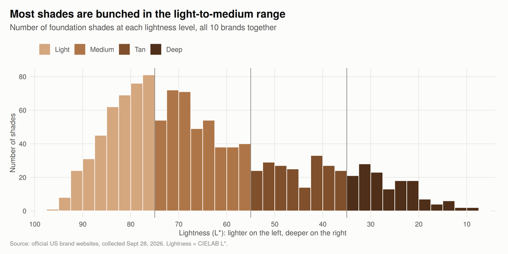

```r
p_hist <- ggplot(shades, aes(x = L_star, fill = depth_band)) +
  geom_histogram(breaks = seq(5, 100, by = 2.5), colour = surface, linewidth = 0.4) +
  geom_vline(xintercept = c(35, 55, 75), colour = muted, linewidth = 0.4) +
  scale_x_reverse(breaks = seq(10, 100, 10), expand = expansion(mult = 0.01)) +
  scale_fill_manual(values = band_colors, drop = FALSE) +
  labs(title = "Most shades are bunched in the light-to-medium range",
       subtitle = "Number of foundation shades at each lightness level, all 10 brands together",
       x = x_lab, y = "Number of shades", caption = source_note) +
  theme_shade()
p_hist
```

```r
save_chart(p_hist, "01_lightness_histogram.png", height = 5)
```

## 8.2 Each brand’s spread

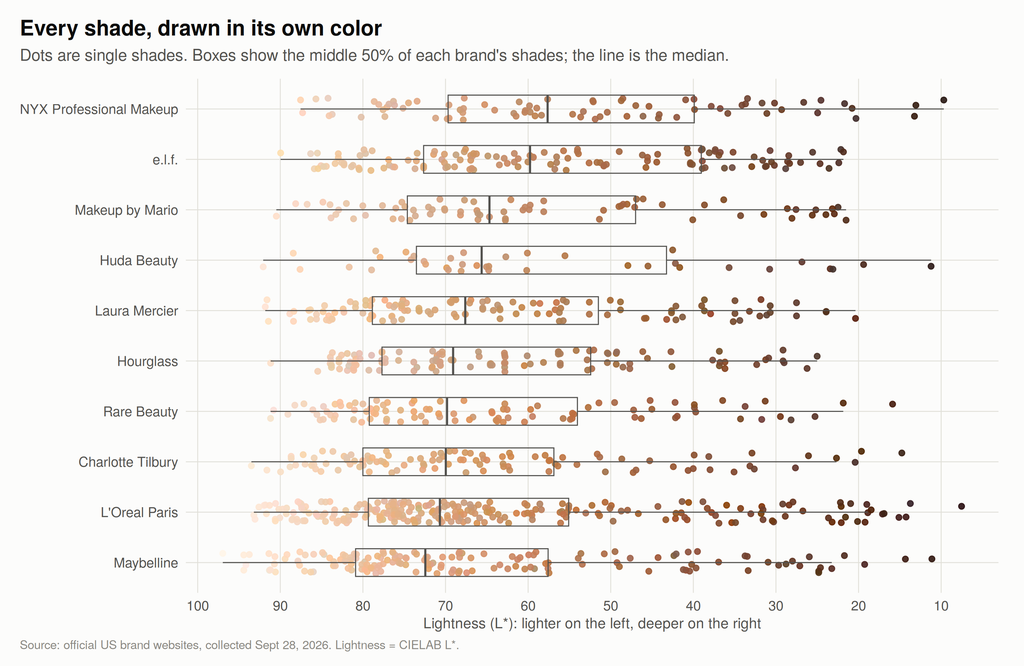

```r
brand_by_median <- shades %>% group_by(brand) %>% summarise(med = median(L_star)) %>% arrange(med)

set.seed(2026)  # makes the random jitter the same every time
p_box <- ggplot(shades, aes(x = L_star, y = factor(brand, levels = rev(brand_by_median$brand)))) +
  geom_jitter(aes(colour = hex), height = 0.22, width = 0, size = 1.6, alpha = 0.9) +
  geom_boxplot(fill = NA, colour = ink2, outlier.shape = NA, width = 0.55, linewidth = 0.35) +
  scale_colour_identity() +
  scale_x_reverse(breaks = seq(10, 100, 10)) +
  labs(title = "Every shade, drawn in its own color",
       subtitle = "Dots are single shades. Boxes show the middle 50% of each brand's shades; the line is the median.",
       x = x_lab, y = NULL, caption = source_note) +
  theme_shade()
p_box
```

```r
save_chart(p_box, "02_brand_boxplots.png", height = 6.5)
```

# 9 Descriptive statistics

```r
brand_stats <- shades %>%
  group_by(brand) %>%
  summarise(products = n_distinct(product),
            shades   = n(),
            lightest = max(L_star), deepest = min(L_star),
            range    = lightest - deepest,
            mean     = mean(L_star), median = median(L_star), sd = sd(L_star),
            q1 = quantile(L_star, 0.25), q3 = quantile(L_star, 0.75),
            pct_deep       = mean(depth_band == "Deep"),
            pct_deeper_half = mean(depth_band %in% c("Tan", "Deep")),
            .groups = "drop") %>%
  arrange(desc(pct_deeper_half))

brand_stats %>%
  mutate(across(lightest:q3, ~ round(.x, 1)),
         across(starts_with("pct"), ~ percent(.x, accuracy = 0.1))) %>%
  knitr::kable(caption = "Lightness (L*) by brand. pct_deeper_half = Tan + Deep bands (L* below 55).")
```

Lightness (L*) by brand. pct_deeper_half = Tan + Deep bands (L* below 55).

| brand | products | shades | lightest | deepest | range | mean | median | sd | q1 | q3 | pct_deep | pct_deeper_half |
| --- | --- | --- | --- | --- | --- | --- | --- | --- | --- | --- | --- | --- |
| NYX Professional Makeup | 3 | 79 | 87.6 | 9.7 | 77.9 | 54.5 | 57.6 | 20.1 | 39.9 | 69.7 | 20.3% | 49.4% |
| e.l.f. | 5 | 129 | 90.0 | 21.8 | 68.1 | 57.4 | 59.8 | 19.0 | 39.0 | 72.7 | 14.7% | 41.9% |
| Makeup by Mario | 2 | 71 | 90.5 | 21.5 | 69.0 | 59.5 | 64.7 | 19.6 | 47.0 | 74.6 | 16.9% | 35.2% |
| Huda Beauty | 1 | 38 | 92.1 | 11.2 | 80.8 | 59.3 | 65.6 | 20.9 | 43.2 | 73.5 | 15.8% | 31.6% |
| Rare Beauty | 2 | 96 | 91.2 | 15.9 | 75.3 | 64.9 | 69.8 | 18.3 | 54.0 | 79.2 | 9.4% | 29.2% |
| Hourglass | 4 | 115 | 91.2 | 25.0 | 66.2 | 63.8 | 69.1 | 16.4 | 52.4 | 77.7 | 7.0% | 28.7% |
| Laura Mercier | 6 | 123 | 91.8 | 20.4 | 71.4 | 63.9 | 67.6 | 18.4 | 51.5 | 78.9 | 11.4% | 26.8% |
| L’Oreal Paris | 11 | 245 | 93.2 | 7.5 | 85.7 | 64.9 | 70.7 | 20.7 | 55.1 | 79.3 | 13.1% | 24.5% |
| Maybelline | 8 | 156 | 97.0 | 11.1 | 85.8 | 66.9 | 72.4 | 19.9 | 57.6 | 80.9 | 10.9% | 23.7% |
| Charlotte Tilbury | 4 | 106 | 93.5 | 14.8 | 78.7 | 66.0 | 70.0 | 18.5 | 56.9 | 80.0 | 8.5% | 22.6% |

```r
write_csv(brand_stats, "output/tables/brand_summary.csv")
```

```r
overall <- shades %>% summarise(shades = n(), products = n_distinct(paste(brand, product)),
                                min = min(L_star), q1 = quantile(L_star, .25), median = median(L_star),
                                mean = mean(L_star), q3 = quantile(L_star, .75), max = max(L_star), sd = sd(L_star))
knitr::kable(mutate(overall, across(min:sd, ~ round(.x, 1))), caption = "All shades together")
```

All shades together

| shades | products | min | q1 | median | mean | q3 | max | sd |
| --- | --- | --- | --- | --- | --- | --- | --- | --- |
| 1158 | 46 | 7.5 | 49.6 | 67.8 | 63 | 78.3 | 97 | 19.6 |

```r
band_share <- shades %>% count(depth_band) %>% mutate(share = n / sum(n))
knitr::kable(mutate(band_share, share = percent(share, accuracy = 0.1)), caption = "Shades in each depth band")
```

Shades in each depth band

| depth_band | n | share |
| --- | --- | --- |
| Light | 397 | 34.3% |
| Medium | 416 | 35.9% |
| Tan | 203 | 17.5% |
| Deep | 142 | 12.3% |

```r
gaps <- shades %>% filter(!is.na(gap_to_next))

product_stats <- shades %>%
  group_by(brand, product, product_type) %>%
  summarise(shades = n(), lightest = max(L_star), deepest = min(L_star),
            pct_in_deeper_half_of_own_range = mean(product_half == "deeper half"),
            .groups = "drop") %>%
  left_join(gaps %>%
              group_by(brand, product) %>%
              summarise(median_gap_lighter_half = median(gap_to_next[gap_half == "lighter half"]),
                        median_gap_deeper_half  = median(gap_to_next[gap_half == "deeper half"]),
                        gaps_lighter = sum(gap_half == "lighter half"),
                        gaps_deeper  = sum(gap_half == "deeper half"),
                        .groups = "drop"),
            by = c("brand", "product"))

product_stats %>%
  arrange(pct_in_deeper_half_of_own_range) %>%
  mutate(across(c(lightest, deepest, starts_with("median")), ~ round(.x, 1)),
         pct_in_deeper_half_of_own_range = percent(pct_in_deeper_half_of_own_range, accuracy = 1)) %>%
  select(-gaps_lighter, -gaps_deeper) %>%
  knitr::kable(caption = "Every product. If shades were spread evenly, 50% would sit in the deeper half of the product's own range.")
```

Every product. If shades were spread evenly, 50% would sit in the deeper half of the product’s own range.

| brand | product | product_type | shades | lightest | deepest | pct_in_deeper_half_of_own_range | median_gap_lighter_half | median_gap_deeper_half |
| --- | --- | --- | --- | --- | --- | --- | --- | --- |
| Laura Mercier | Real Flawless Weightless Perfecting Waterproof Foundation | Foundation | 31 | 91.8 | 20.4 | 13% | 0.6 | 8.8 |
| Maybelline | Fit Me Dewy + Smooth Foundation | Foundation | 20 | 94.4 | 24.8 | 15% | 1.2 | 17.3 |
| L’Oreal Paris | Infallible Pro-Matte Foundation | Foundation | 22 | 89.7 | 18.5 | 18% | 1.1 | 10.3 |
| L’Oreal Paris | Infallible 32H Fresh Wear Foundation | Foundation | 39 | 93.2 | 13.7 | 21% | 1.0 | 3.9 |
| Rare Beauty | True to Myself Natural Matte Longwear Foundation | Foundation | 48 | 90.8 | 15.9 | 21% | 0.8 | 3.1 |
| Maybelline | Super Stay 24HR Skin Tint with Vitamin C | Skin tint | 18 | 91.2 | 21.7 | 22% | 1.4 | 8.2 |
| Maybelline | Fit Me Matte + Poreless Foundation | Foundation | 40 | 94.4 | 24.8 | 22% | 0.7 | 2.1 |
| Charlotte Tilbury | Airbrush Flawless Foundation | Foundation | 44 | 91.6 | 14.8 | 23% | 0.8 | 4.1 |
| Laura Mercier | Flawless Lumiere Foundation | Foundation | 30 | 84.4 | 33.2 | 23% | 0.9 | 3.5 |
| Charlotte Tilbury | Hollywood Flawless Filter | Glow filter | 12 | 93.5 | 38.1 | 25% | 2.6 | 10.4 |
| L’Oreal Paris | Infallible Pro-Glow Foundation | Foundation | 12 | 84.0 | 41.5 | 25% | 1.7 | 10.5 |
| Maybelline | Dream Urban Cover Flawless Coverage Foundation SPF 50 | Foundation | 8 | 91.3 | 42.4 | 25% | 4.9 | 14.6 |
| Maybelline | Instant Age Rewind Eraser Treatment Makeup | Foundation | 16 | 90.6 | 40.2 | 25% | 1.6 | 8.5 |
| L’Oreal Paris | Infallible Cushion Foundation | Foundation | 19 | 93.1 | 21.0 | 26% | 2.0 | 8.1 |
| Charlotte Tilbury | Charlotte’s Beautiful Skin Foundation | Foundation | 30 | 88.8 | 32.6 | 27% | 1.3 | 5.2 |
| L’Oreal Paris | True Match Super-Blendable Foundation | Foundation | 47 | 92.6 | 7.5 | 28% | 1.0 | 2.5 |
| Hourglass | Illusion Luminous Glow Foundation SPF 30 | Foundation | 32 | 84.0 | 29.0 | 28% | 1.1 | 2.5 |
| Laura Mercier | Tinted Moisturizer Light Revealer SPF 25 | Skin tint | 14 | 84.1 | 32.0 | 29% | 2.1 | 4.5 |
| Maybelline | Super Stay Lumi-Matte Foundation | Foundation | 24 | 89.4 | 14.3 | 29% | 1.4 | 5.1 |
| Charlotte Tilbury | Unreal Skin Sheer Glow Tint Hydrating Foundation Stick | Foundation | 20 | 85.9 | 20.4 | 30% | 1.8 | 6.2 |
| L’Oreal Paris | Age Perfect Radiant Serum Foundation SPF 50 | Foundation | 30 | 89.3 | 18.9 | 30% | 1.3 | 3.6 |
| L’Oreal Paris | Lumi Le Glow Skin Tint | Skin tint | 16 | 87.5 | 16.9 | 31% | 3.1 | 7.4 |
| Huda Beauty | Easy Blur Natural Airbrush Foundation with Niacinamide | Foundation | 38 | 92.1 | 11.2 | 32% | 1.0 | 3.4 |
| Hourglass | Vanish Seamless Finish Foundation Stick | Foundation | 33 | 91.2 | 25.0 | 33% | 1.0 | 3.3 |
| Hourglass | Veil Hydrating Skin Tint | Skin tint | 18 | 83.7 | 30.9 | 33% | 1.4 | 0.5 |
| Maybelline | Dream Radiant Liquid Hydrating Foundation | Foundation | 6 | 97.0 | 28.8 | 33% | 7.8 | 24.8 |
| Maybelline | Lifter Plump & Glow Foundation | Foundation | 24 | 83.5 | 11.1 | 33% | 2.0 | 4.0 |
| NYX Professional Makeup | Make ’Em Wonder Soft Matte Buildable Foundation | Foundation | 45 | 87.6 | 9.7 | 33% | 1.1 | 1.7 |
| e.l.f. | Halo Glow Liquid Filter | Glow filter | 15 | 82.3 | 28.4 | 33% | 1.5 | 5.4 |
| Makeup by Mario | SurrealSkin Natural Finish Foundation | Foundation | 32 | 86.8 | 21.5 | 34% | 1.0 | 2.5 |
| Rare Beauty | Liquid Touch Weightless Foundation | Foundation | 48 | 91.2 | 25.3 | 35% | 0.7 | 2.2 |
| Makeup by Mario | SurrealSkin Foundation | Foundation | 39 | 90.5 | 22.5 | 36% | 1.1 | 1.3 |
| e.l.f. | Soft Glam Satin Foundation | Foundation | 36 | 86.3 | 22.4 | 36% | 0.8 | 1.8 |
| L’Oreal Paris | Infallible Skin Ink 2-in-1 Foundation Concealer | Foundation | 22 | 90.1 | 19.0 | 36% | 1.8 | 4.4 |
| Hourglass | Ambient Soft Glow Foundation | Foundation | 32 | 85.5 | 26.2 | 38% | 0.9 | 1.8 |
| Laura Mercier | Tinted Moisturizer Blurred Matte SPF 30 | Skin tint | 20 | 86.3 | 23.9 | 40% | 2.1 | 3.6 |
| Laura Mercier | Tinted Moisturizer Natural Dewy SPF 30 | Skin tint | 20 | 86.3 | 23.9 | 40% | 2.1 | 3.6 |
| NYX Professional Makeup | Buttermelt Glaze Soft Glow Skin Tint SPF 30 | Skin tint | 10 | 77.1 | 13.1 | 40% | 7.5 | 8.2 |
| L’Oreal Paris | True Match Hyaluron Tinted Balm Foundation | Foundation | 12 | 88.0 | 30.3 | 42% | 4.1 | 7.0 |
| NYX Professional Makeup | Bare With Me Blur Tint Foundation | Foundation | 24 | 84.2 | 20.3 | 46% | 1.1 | 2.1 |
| e.l.f. | Camo CC Cream | CC cream | 30 | 83.0 | 21.8 | 47% | 1.6 | 1.9 |
| L’Oreal Paris | True Match Lumi Healthy Luminous Makeup | Foundation | 14 | 87.6 | 49.7 | 50% | 2.0 | 0.7 |
| Laura Mercier | Tinted Blur Balm | Skin tint | 8 | 83.7 | 31.1 | 50% | 8.1 | 6.9 |
| e.l.f. | Halo Glow Skin Tint SPF 50 | Skin tint | 18 | 85.9 | 23.6 | 50% | 1.3 | 1.8 |
| e.l.f. | Hydrating Camo CC Cream | CC cream | 30 | 90.0 | 30.7 | 53% | 2.0 | 1.7 |
| L’Oreal Paris | Visible Lift Serum Absolute Advanced Age-Reversing Makeup | Foundation | 12 | 90.6 | 65.9 | 67% | 4.0 | 0.8 |

```r
write_csv(product_stats, "output/tables/product_summary.csv")
```

# 10 Is the spacing difference real? (statistical test)

The table above suggests deep shades are spaced further apart than light shades. Before calling that a finding, I checked whether it could just be chance.

**Why this test.** Each product gives me a *pair* of numbers: the typical gap between neighboring shades in its lighter half, and in its deeper half. Comparing pairs inside the same product controls for differences between products (price, formula, number of shades). The gaps are skewed and not bell-shaped, and I only have a few dozen products, so I used the **Wilcoxon signed-rank test**. It is the standard test for paired data that does not assume a bell curve. I only used products with at least two gaps in each half.

```r
paired <- product_stats %>% filter(gaps_lighter >= 2, gaps_deeper >= 2)

wtest <- wilcox.test(paired$median_gap_deeper_half, paired$median_gap_lighter_half,
                     paired = TRUE, exact = FALSE)
n_products_tested <- nrow(paired)
n_deeper_wider    <- sum(paired$median_gap_deeper_half > paired$median_gap_lighter_half)
typical_light_gap <- median(paired$median_gap_lighter_half)
typical_deep_gap  <- median(paired$median_gap_deeper_half)
gap_ratio         <- typical_deep_gap / typical_light_gap

tibble(`Products tested` = n_products_tested,
       `Deeper shades spaced wider` = n_deeper_wider,
       `Typical gap, lighter half (L*)` = round(typical_light_gap, 2),
       `Typical gap, deeper half (L*)`  = round(typical_deep_gap, 2),
       `p-value` = signif(wtest$p.value, 2)) %>%
  knitr::kable()
```

| Products tested | Deeper shades spaced wider | Typical gap, lighter half (L*) | Typical gap, deeper half (L*) | p-value |
| --- | --- | --- | --- | --- |
| 45 | 40 | 1.36 | 3.64 | 3e-07 |

**What the test does not show:** these products are not a random sample of all foundations, so this does not prove the pattern holds for every brand. It shows the pattern is strong and consistent across the products I studied.

# 11 Charts

## 11.1 Chart 1: Every shade, lightest to deepest

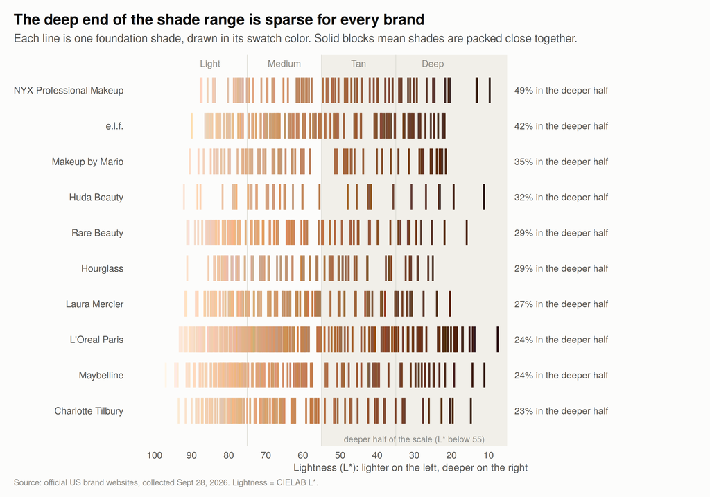

```r
brand_rank <- brand_stats %>% arrange(pct_deeper_half) %>% pull(brand)
strip_data <- shades %>% mutate(brand = factor(brand, levels = brand_rank))
label_data <- brand_stats %>%
  mutate(brand = factor(brand, levels = brand_rank),
         label = paste0(percent(pct_deeper_half, accuracy = 1), " in the deeper half"))

p_strip <- ggplot(strip_data) +
  annotate("rect", xmin = 55, xmax = 5, ymin = -Inf, ymax = Inf, fill = "#f1efe9") +
  geom_vline(xintercept = c(35, 55, 75), colour = grid, linewidth = 0.4) +
  geom_segment(aes(x = L_star, xend = L_star,
                   y = as.numeric(brand) - 0.36, yend = as.numeric(brand) + 0.36, colour = hex),
               linewidth = 0.9) +
  geom_text(data = label_data, aes(x = 3, y = as.numeric(brand), label = label),
            hjust = 0, size = 3.3, colour = ink2, family = chart_font) +
  annotate("text", x = c(85, 65, 45, 25), y = length(brand_rank) + 0.75,
           label = band_levels, colour = muted, size = 3.3, family = chart_font) +
  annotate("text", x = 30, y = 0.2, label = "deeper half of the scale (L* below 55)",
           colour = muted, size = 3, family = chart_font) +
  scale_colour_identity() +
  scale_x_reverse(limits = c(100, -38), breaks = seq(10, 100, 10)) +
  scale_y_continuous(breaks = seq_along(brand_rank), labels = brand_rank,
                     limits = c(0, length(brand_rank) + 1), expand = c(0, 0)) +
  labs(title = "The deep end of the shade range is sparse for every brand",
       subtitle = "Each line is one foundation shade, drawn in its swatch color. Solid blocks mean shades are packed close together.",
       x = x_lab, y = NULL, caption = source_note) +
  theme_shade() +
  theme(panel.grid.major.y = element_blank(), panel.grid.major.x = element_blank())
p_strip
```

```r
save_chart(p_strip, "03_shade_strip_by_brand.png", width = 12, height = 7)
```

**What it shows:** the light end of every brand’s row is a solid block of color, while the deep end breaks into separate lines with gaps between them.

## 11.2 Chart 2: How each brand’s shades split across the four bands

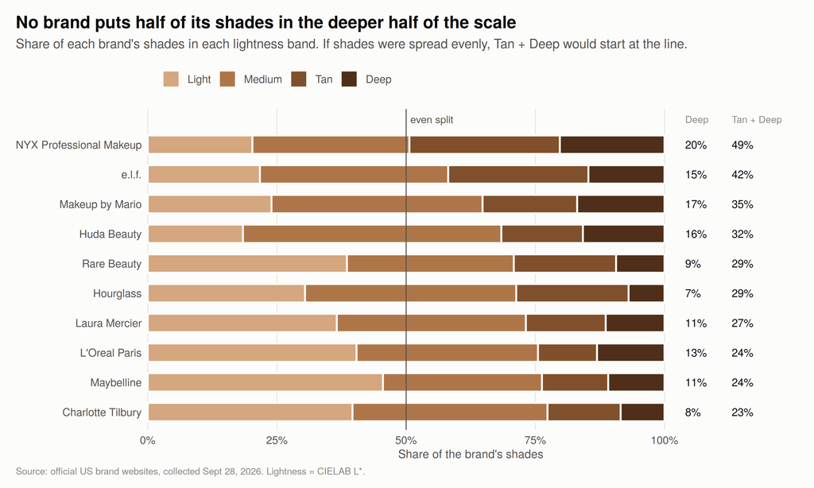

```r
band_by_brand <- shades %>%
  count(brand, depth_band) %>%
  group_by(brand) %>% mutate(share = n / sum(n)) %>% ungroup() %>%
  mutate(brand = factor(brand, levels = brand_rank))
number_cols <- brand_stats %>%
  mutate(brand = factor(brand, levels = brand_rank),
         deep = percent(pct_deep, accuracy = 1), deeper = percent(pct_deeper_half, accuracy = 1))
top_y <- length(brand_rank) + 0.85

p_bands <- ggplot(band_by_brand, aes(x = share, y = brand, fill = depth_band)) +
  geom_col(width = 0.62, colour = surface, linewidth = 0.8, position = position_stack(reverse = TRUE)) +
  geom_vline(xintercept = 0.5, colour = ink2, linewidth = 0.4) +
  annotate("text", x = 0.508, y = top_y, label = "even split", hjust = 0,
           colour = ink2, size = 3.2, family = chart_font) +
  geom_text(data = number_cols, aes(x = 1.04, y = brand, label = deep), inherit.aes = FALSE,
            hjust = 0, size = 3.4, colour = ink, family = chart_font) +
  geom_text(data = number_cols, aes(x = 1.13, y = brand, label = deeper), inherit.aes = FALSE,
            hjust = 0, size = 3.4, colour = ink, family = chart_font) +
  annotate("text", x = c(1.04, 1.13), y = top_y, label = c("Deep", "Tan + Deep"), hjust = 0,
           colour = muted, size = 3, family = chart_font) +
  scale_fill_manual(values = band_colors) +
  scale_x_continuous(labels = percent, breaks = seq(0, 1, 0.25), expand = c(0, 0)) +
  scale_y_discrete(expand = expansion(add = c(0.6, 1.2))) +
  coord_cartesian(xlim = c(0, 1.25), clip = "off") +
  labs(title = "No brand puts half of its shades in the deeper half of the scale",
       subtitle = "Share of each brand's shades in each lightness band. If shades were spread evenly, Tan + Deep would start at the line.",
       x = "Share of the brand's shades", y = NULL, caption = source_note) +
  theme_shade() +
  theme(panel.grid.major.y = element_blank())
p_bands
```

```r
save_chart(p_bands, "04_depth_bands_by_brand.png", height = 6)
```

## 11.3 Chart 3: Deep shades are spaced further apart

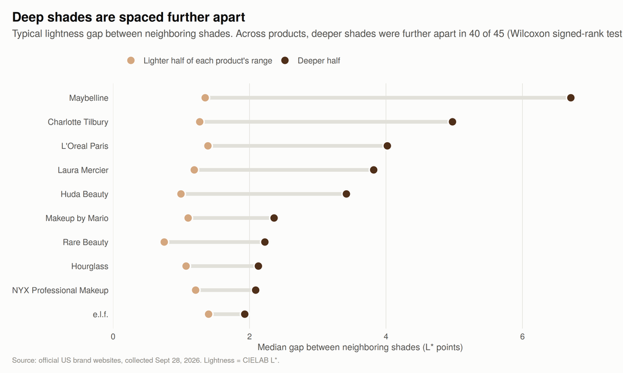

```r
spacing_by_brand <- gaps %>%
  group_by(brand, gap_half) %>%
  summarise(median_gap = median(gap_to_next), .groups = "drop") %>%
  pivot_wider(names_from = gap_half, values_from = median_gap) %>%
  arrange(`deeper half`) %>%
  mutate(brand = factor(brand, levels = brand))
write_csv(spacing_by_brand, "output/tables/spacing_by_brand.csv")

spacing_long <- spacing_by_brand %>%
  pivot_longer(-brand, names_to = "half", values_to = "gap") %>%
  mutate(half = factor(half, levels = c("lighter half", "deeper half"),
                       labels = c("Lighter half of each product's range", "Deeper half")))

p_spacing <- ggplot(spacing_by_brand, aes(y = brand)) +
  geom_segment(aes(x = `lighter half`, xend = `deeper half`, yend = brand),
               colour = grid, linewidth = 2) +
  geom_point(data = spacing_long, aes(x = gap, fill = half), shape = 21, size = 4,
             colour = surface, stroke = 1.2) +
  scale_fill_manual(values = c(band_colors[["Light"]], band_colors[["Deep"]])) +
  scale_x_continuous(limits = c(0, NA), expand = expansion(mult = c(0, 0.08))) +
  labs(title = "Deep shades are spaced further apart",
       subtitle = paste0("Typical lightness gap between neighboring shades. Across products, deeper shades were further apart in ",
                         n_deeper_wider, " of ", n_products_tested, " (Wilcoxon signed-rank test, p < 0.001)."),
       x = "Median gap between neighboring shades (L* points)", y = NULL, caption = source_note) +
  theme_shade() +
  theme(panel.grid.major.y = element_blank())
p_spacing
```

```r
save_chart(p_spacing, "05_spacing_light_vs_deep.png", height = 6)
```

## 11.4 Chart 4: More shades does not mean more deep shades

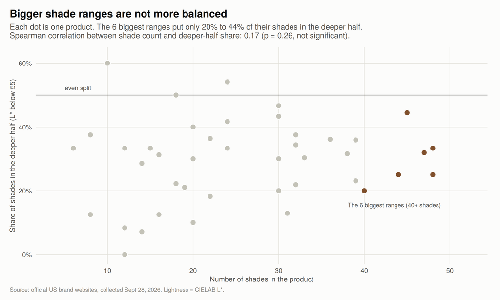

```r
size_vs_balance <- shades %>%
  group_by(brand, product) %>%
  summarise(shades = n(), pct_deeper = mean(depth_band %in% c("Tan", "Deep")), .groups = "drop") %>%
  mutate(big_range = shades >= 40)
spearman <- cor.test(size_vs_balance$shades, size_vs_balance$pct_deeper, method = "spearman", exact = FALSE)
big <- size_vs_balance %>% filter(big_range)

p_size <- ggplot(size_vs_balance, aes(x = shades, y = pct_deeper)) +
  geom_hline(yintercept = 0.5, colour = ink2, linewidth = 0.4) +
  annotate("text", x = 5, y = 0.515, label = "even split", hjust = 0, vjust = 0,
           colour = ink2, size = 3.2, family = chart_font) +
  geom_point(aes(fill = big_range), size = 3.4, shape = 21, colour = surface, stroke = 0.8) +
  annotate("text", x = 43.5, y = min(big$pct_deeper) - 0.045, hjust = 0.5, size = 3.1, colour = ink2,
           family = chart_font, label = paste0("The ", nrow(big), " biggest ranges (40+ shades)")) +
  scale_fill_manual(values = c(`TRUE` = band_colors[["Tan"]], `FALSE` = "#c3c2b7"), guide = "none") +
  scale_y_continuous(labels = percent, limits = c(0, 0.62)) +
  scale_x_continuous(limits = c(4, 52), breaks = seq(10, 50, 10)) +
  labs(title = "Bigger shade ranges are not more balanced",
       subtitle = paste0("Each dot is one product. The ", nrow(big), " biggest ranges put only ",
                         percent(min(big$pct_deeper), accuracy = 1), " to ", percent(max(big$pct_deeper), accuracy = 1),
                         " of their shades in the deeper half.\nSpearman correlation between shade count and deeper-half share: ",
                         round(spearman$estimate, 2), " (p = ", round(spearman$p.value, 2), ", not significant)."),
       x = "Number of shades in the product", y = "Share of shades in the deeper half (L* below 55)",
       caption = source_note) +
  theme_shade()
p_size
```

```r
save_chart(p_size, "06_shade_count_vs_balance.png", height = 6)
```

## 11.5 Chart 5: The full shade wall, product by product

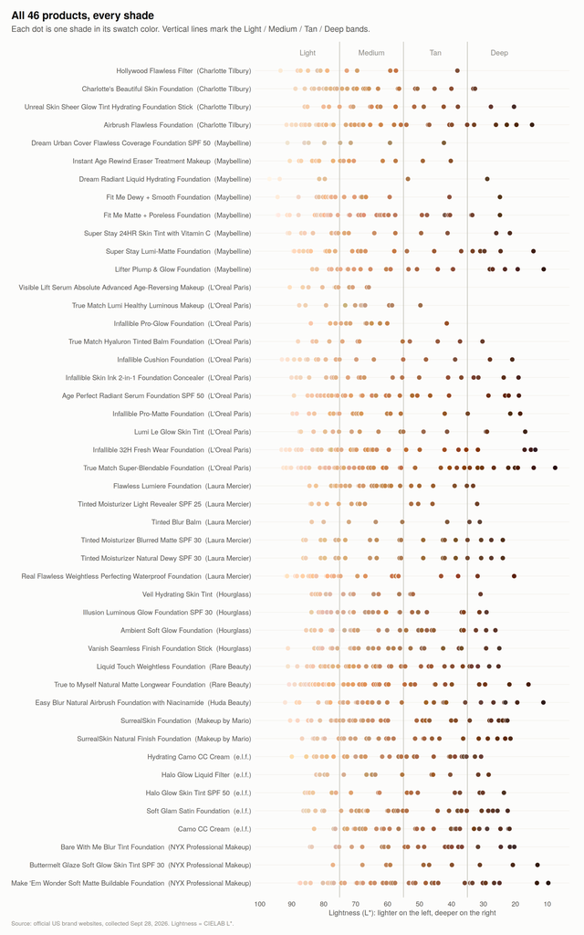

```r
wall <- shades %>%
  mutate(product_label = paste0(product, "  (", brand, ")"),
         brand = factor(brand, levels = brand_rank))
wall_order <- wall %>% group_by(brand, product_label) %>% summarise(deep = min(L_star), .groups = "drop") %>%
  arrange(brand, desc(deep)) %>% pull(product_label)

p_wall <- ggplot(wall, aes(y = factor(product_label, levels = rev(wall_order)))) +
  geom_vline(xintercept = c(35, 55, 75), colour = "#c3c2b7", linewidth = 0.4) +
  annotate("text", x = c(85, 65, 45, 25), y = length(wall_order) + 1, label = band_levels,
           colour = muted, size = 3.2, family = chart_font) +
  geom_point(aes(x = L_star, fill = hex), shape = 21, size = 2.6, colour = surface, stroke = 0.35) +
  scale_fill_identity() +
  scale_x_reverse(breaks = seq(10, 100, 10)) +
  scale_y_discrete(expand = expansion(add = c(0.8, 1.6))) +
  labs(title = "All 46 products, every shade",
       subtitle = "Each dot is one shade in its swatch color. Vertical lines mark the Light / Medium / Tan / Deep bands.",
       x = x_lab, y = NULL, caption = source_note) +
  theme_shade(base_size = 10.5) +
  theme(panel.grid.major.y = element_line(colour = "#f1efe9", linewidth = 0.3),
        panel.grid.major.x = element_blank())
p_wall
```

```r
save_chart(p_wall, "07_shade_wall_all_products.png", width = 11, height = 16)
```

# 12 Findings

- A person with deep skin has fewer shades to choose from **and** bigger jumps between them, so their closest shade is more likely to be a noticeable mismatch. Someone with light skin has many near-identical options.
- A long shade list on the box is not enough to judge inclusivity. How the shades are *spaced* matters as much as how many there are.
- Brands may be placing shades where they expect the most sales. This data can’t show why shades are spread this way, only that they are.

# 13 Limitations

- **Screen colors, not real makeup.** Swatches are digital images. Lighting, photography, compression and each screen change how a color looks. This measures what shoppers *see* online, not the foundation on skin.
- **Two kinds of swatches.** Seven brands use color codes; three use photos, which I averaged. Brands don’t calibrate swatches against each other, so small cross-brand differences in lightness should be read with caution. The spacing and within-product results compare a brand only with itself, so they are more reliable.
- **Swatches aren’t always accurate.** Some brands give two different shades the same color (8 pairs), and in 26 spots a higher-numbered shade has a swatch more than 5 points lighter than the one before it (Section 7.1).
- **Lightness only.** Undertone (warm, cool, olive) also matters for a match. I saved the a* and b* color values so undertone can be studied next.
- **One day, ten brands.** Shade lineups change, and these 10 brands are not a random sample of the whole market. Brands known for very wide ranges are not in this list.
- **The band cutoffs are a choice.** I tied them to the Monk Skin Tone Scale’s span, and the product-level results (own-range share and spacing) do not depend on them.

```r
# Sensitivity check: add back the three clearance products (only the shades their pages still showed)
all_rows <- shades_raw %>%
  mutate(L = lightness_Lstar(decode_colour(hex)[, "r"], decode_colour(hex)[, "g"], decode_colour(hex)[, "b"]))
tibble(dataset = c("Main analysis", "With the 3 clearance products added back"),
       `number of shades` = c(nrow(shades), nrow(all_rows)),
       `share below L* 55` = percent(c(mean(shades$L_star < 55), mean(all_rows$L < 55)), accuracy = 0.1),
       `share below L* 35` = percent(c(mean(shades$L_star < 35), mean(all_rows$L < 35)), accuracy = 0.1)) %>%
  knitr::kable(caption = "The overall result barely moves if the dropped products are included")
```

The overall result barely moves if the dropped products are included

| dataset | number of shades | share below L* 55 | share below L* 35 |
| --- | --- | --- | --- |
| Main analysis | 1158 | 29.8% | 12.3% |
| With the 3 clearance products added back | 1209 | 30.5% | 12.7% |

# 14 Conclusion

All ten brands offer shades from very light to very deep, so **reach** is not the main problem. The problem is **balance and spacing**. Across 1,158 shades, the lighter half of the scale holds about 70% of the shades, and deep shades are spaced about 2.7 times further apart than light ones. The spacing difference holds in 40 of 45 products. A good next step would add undertone (a* and b*) and more brands, and compare swatches with real product photos under the same light.

# 15 All the R code

```r
knitr::opts_chunk$set(echo = TRUE, message = FALSE, warning = FALSE,
                      fig.width = 10, fig.height = 6, dpi = 150, fig.align = "center")
# Run every chunk from the project folder (one level up from /analysis).
# If you run the plain script analysis/shade_analysis.R instead, open the .Rproj first so the
# working directory is the project folder.
knitr::opts_knit$set(root.dir = normalizePath(".."))
# Packages used (all free on CRAN):
#   install.packages(c("dplyr", "tidyr", "readr", "stringr", "forcats",
#                      "ggplot2", "farver", "scales", "knitr", "rmarkdown"))
library(dplyr)    # data cleaning
library(tidyr)    # reshaping tables
library(readr)    # reading and writing CSV files
library(stringr)  # text cleaning
library(forcats)  # ordering categories in charts
library(ggplot2)  # charts
library(farver)   # color conversion (used to double-check my own formula)
library(scales)   # percent labels

dir.create("data/clean", showWarnings = FALSE, recursive = TRUE)
dir.create("output/charts", showWarnings = FALSE, recursive = TRUE)
dir.create("output/tables", showWarnings = FALSE, recursive = TRUE)
shades_raw <- read_csv("data/raw/shades_raw.csv", col_types = cols(.default = col_character()))
products   <- read_csv("data/raw/products.csv",   col_types = cols(.default = col_character()))

products %>%
  count(brand, included, name = "products") %>%
  pivot_wider(names_from = included, values_from = products, values_fill = 0,
              names_prefix = "included_") %>%
  knitr::kable(caption = "Products collected per brand")
products %>%
  filter(included == "no") %>%
  select(brand, product, shades_collected, exclusion_reason) %>%
  knitr::kable()
tibble::tribble(
  ~column,          ~meaning,
  "brand",          "Brand name",
  "product",        "Product name as shown on the brand's site",
  "product_type",   "Foundation, Skin tint, CC cream or Glow filter (from the product name)",
  "shade",          "Shade name exactly as the site shows it",
  "hex",            "Swatch color as a HEX code, for example #BA8656",
  "R, G, B",        "Red, green and blue parts of the color (0 to 255)",
  "L_star",         "Lightness from 0 (black) to 100 (white): the main measure",
  "a_star, b_star", "The other two CIELAB color numbers (redness and yellowness), kept for future undertone work",
  "depth_band",     "Light, Medium, Tan or Deep, from L* (see Section 7)",
  "rank_in_product","1 = the product's lightest shade",
  "gap_to_next",    "Lightness difference to the next deeper shade in the same product",
  "product_half",   "Whether the shade is in the lighter or deeper half of its own product's range",
  "swatch_type",    "Color code or image",
  "in_stock",       "TRUE/FALSE where the site showed stock; blank where it did not",
  "source_url",     "Product page the swatch came from",
  "date_collected", "2026-09-28"
) %>% knitr::kable()
cleaning_log <- tibble(step = "All swatches collected", rows = nrow(shades_raw))

# 1. Keep only the products that are part of the study
shades <- shades_raw %>%
  semi_join(filter(products, included == "yes"), by = c("brand", "product"))
cleaning_log <- add_row(cleaning_log, step = "Dropped 3 clearance products", rows = nrow(shades))

# 2. Tidy the text: trim spaces and use one kind of dash
shades <- shades %>%
  mutate(across(c(brand, product, shade), ~ str_squish(str_replace_all(.x, "[\\u2013\\u2014]", "-"))),
         hex      = str_to_upper(str_trim(hex)),
         in_stock = as.logical(in_stock))

# 3. Checks (each should be zero)
checks <- tibble(
  check = c("Missing brand, product, shade or HEX",
            "HEX codes that are not a valid #RRGGBB code",
            "Duplicate rows (same brand + product + shade)"),
  count = c(sum(is.na(shades$brand) | is.na(shades$product) | is.na(shades$shade) | is.na(shades$hex)),
            sum(!str_detect(shades$hex, "^#[0-9A-F]{6}$")),
            sum(duplicated(select(shades, brand, product, shade))))
)
knitr::kable(checks, caption = "Data checks")
stopifnot(all(checks$count == 0))

# 4. Label each product's type from its name (my rule, applied the same way to every brand)
shades <- shades %>%
  mutate(product_type = case_when(
    str_detect(product, "CC Cream")              ~ "CC cream",
    str_detect(product, "Filter")                ~ "Glow filter",
    str_detect(product, "Foundation|Makeup")     ~ "Foundation",
    str_detect(product, "Tint|Tinted|Balm")      ~ "Skin tint",
    TRUE                                         ~ "Foundation"))

cleaning_log <- add_row(cleaning_log, step = "Final clean dataset", rows = nrow(shades))
knitr::kable(cleaning_log, caption = "Rows at each cleaning step")
repeated_colors <- shades %>%
  group_by(brand, product, hex) %>%
  filter(n() > 1) %>%
  summarise(shades = paste(shade, collapse = " / "), .groups = "drop")
knitr::kable(repeated_colors, caption = "Shades that share one swatch color within a product")
# Step 1: the sRGB curve, for a 0-255 value
srgb_to_linear <- function(v) {
  v <- v / 255
  ifelse(v <= 0.04045, v / 12.92, ((v + 0.055) / 1.055)^2.4)
}

# Steps 2 and 3: brightness (Y), then lightness (L*)
lightness_Lstar <- function(R, G, B) {
  Y <- 0.2126 * srgb_to_linear(R) + 0.7152 * srgb_to_linear(G) + 0.0722 * srgb_to_linear(B)
  f <- ifelse(Y > (6/29)^3, Y^(1/3), Y / (3 * (6/29)^2) + 4/29)
  116 * f - 16
}

rgb <- decode_colour(shades$hex)   # HEX -> a table of R, G, B
shades <- shades %>%
  mutate(R = rgb[, "r"], G = rgb[, "g"], B = rgb[, "b"],
         L_star = round(lightness_Lstar(R, G, B), 2))

# The other two CIELAB numbers (a* = red vs green, b* = yellow vs blue), from farver
lab <- convert_colour(rgb, from = "rgb", to = "lab")
shades <- shades %>% mutate(a_star = round(lab[, "a"], 2), b_star = round(lab[, "b"], 2))

# Checks: white should be 100, black 0, and my formula should match farver's full conversion
tibble(color = c("#FFFFFF (white)", "#000000 (black)", "#777777 (mid gray)"),
       L_star = round(lightness_Lstar(c(255, 0, 119), c(255, 0, 119), c(255, 0, 119)), 2)) %>%
  knitr::kable(caption = "Sanity check")
cat("Largest difference between my L* and farver's L*:",
    signif(max(abs(shades$L_star - lab[, "l"])), 2), "\n")
shades %>%
  filter(product == "Soft Glam Satin Foundation", shade == "40 Tan Warm") %>%
  select(shade, hex, R, G, B, L_star) %>%
  knitr::kable()
order_flags <- shades %>%
  mutate(shade_number = suppressWarnings(as.numeric(str_extract(shade, "^\\.?\\d+(\\.\\d+)?")))) %>%
  group_by(brand, product) %>%
  # only products where every shade name starts with its own number (no two shades share a number)
  filter(all(!is.na(shade_number)), n_distinct(shade_number) == n()) %>%
  arrange(shade_number, .by_group = TRUE) %>%
  mutate(next_number = lead(shade_number), next_shade = lead(shade),
         lighter_by  = lead(L_star) - L_star) %>%
  ungroup() %>%
  filter(!is.na(next_number), next_number > shade_number, lighter_by > 5)
```

```r
n_numbered_products <- shades %>%
  mutate(shade_number = suppressWarnings(as.numeric(str_extract(shade, "^\\.?\\d+(\\.\\d+)?")))) %>%
  group_by(brand, product) %>% filter(all(!is.na(shade_number)), n_distinct(shade_number) == n()) %>% n_groups()

order_flags %>%
  count(brand, swatch_type, name = "flags") %>%
  knitr::kable(caption = paste0("Out-of-order swatches (", nrow(order_flags), " flags across ",
                                n_numbered_products, " numbered product lines)"))
band_levels <- c("Light", "Medium", "Tan", "Deep")
shades <- shades %>%
  mutate(depth_band = cut(L_star, breaks = c(-Inf, 35, 55, 75, Inf),
                          labels = rev(band_levels), right = FALSE),
         depth_band = factor(depth_band, levels = band_levels))

# The 10 Monk Skin Tone Scale colors (Google, CC BY 4.0), for reference
monk <- tibble(tone = 1:10,
               hex  = c("#F6EDE4", "#F3E7DB", "#F7EAD0", "#EADABA", "#D7BD96",
                        "#A07E56", "#825C43", "#604134", "#3A312A", "#292420"))
monk_rgb <- decode_colour(monk$hex)
monk <- monk %>% mutate(L_star = round(lightness_Lstar(monk_rgb[, "r"], monk_rgb[, "g"], monk_rgb[, "b"]), 1),
                        band = cut(L_star, c(-Inf, 35, 55, 75, Inf), labels = rev(band_levels), right = FALSE))
tibble(band = band_levels,
       `L* range` = c("75 and up", "55 to 75", "35 to 55", "below 35"),
       `Monk tones in this band` = sapply(band_levels, function(b) paste(monk$tone[monk$band == b], collapse = ", "))) %>%
  knitr::kable(caption = "The four depth bands")
shades <- shades %>%
  group_by(brand, product) %>%
  arrange(desc(L_star), .by_group = TRUE) %>%
  mutate(rank_in_product = row_number(),
         product_mid     = (max(L_star) + min(L_star)) / 2,
         product_half    = if_else(L_star >= product_mid, "lighter half", "deeper half"),
         gap_to_next     = round(L_star - lead(L_star), 2),               # to the next deeper shade
         gap_half        = if_else((L_star + lead(L_star)) / 2 >= product_mid,
                                   "lighter half", "deeper half")) %>%
  ungroup()

brand_order_default <- c("e.l.f.", "Maybelline", "Huda Beauty", "Charlotte Tilbury", "Hourglass",
                         "L'Oreal Paris", "Laura Mercier", "NYX Professional Makeup",
                         "Rare Beauty", "Makeup by Mario")

shades_clean <- shades %>%
  mutate(brand = factor(brand, levels = brand_order_default)) %>%
  arrange(brand, product, rank_in_product) %>%
  select(brand, product, product_type, shade, hex, R, G, B, L_star, a_star, b_star,
         depth_band, rank_in_product, gap_to_next, product_half, swatch_type, in_stock,
         source_url, date_collected)
write_csv(shades_clean, "data/clean/shades_clean.csv", na = "")
cat("Saved", nrow(shades_clean), "shades to data/clean/shades_clean.csv\n")
# Chart style: quiet background and grid, so the shade colors are the loudest thing
chart_font <- "sans"  # the computer's default sans-serif font
ink <- "#0b0b0b"; ink2 <- "#52514e"; muted <- "#898781"; grid <- "#e1e0d9"; surface <- "#fcfcfb"
band_colors <- c(Light = "#d4a77f", Medium = "#ae7648", Tan = "#80502c", Deep = "#4f2f19")

theme_shade <- function(base_size = 12) {
  theme_minimal(base_size = base_size, base_family = chart_font) +
    theme(plot.background  = element_rect(fill = surface, colour = NA),
          panel.background = element_rect(fill = surface, colour = NA),
          panel.grid.major = element_line(colour = grid, linewidth = 0.3),
          panel.grid.minor = element_blank(),
          axis.text   = element_text(colour = ink2),
          axis.title  = element_text(colour = ink2, size = rel(0.85)),
          plot.title  = element_text(colour = ink, face = "bold", size = rel(1.25)),
          plot.subtitle = element_text(colour = ink2, size = rel(0.95), margin = margin(b = 10)),
          plot.caption  = element_text(colour = muted, size = rel(0.7), hjust = 0),
          plot.title.position = "plot", plot.caption.position = "plot",
          legend.position = "top", legend.justification = "left",
          legend.title = element_blank(), legend.text = element_text(colour = ink2),
          strip.text = element_text(colour = ink, face = "bold", hjust = 0),
          plot.margin = margin(14, 18, 10, 14))
}
x_lab <- "Lightness (L*): lighter on the left, deeper on the right"
source_note <- "Source: official US brand websites, collected Sept 28, 2026. Lightness = CIELAB L*."
save_chart <- function(plot, file, width = 10, height = 6) {
  ggsave(file.path("output/charts", file), plot, width = width, height = height, dpi = 200, bg = surface)
}
p_hist <- ggplot(shades, aes(x = L_star, fill = depth_band)) +
  geom_histogram(breaks = seq(5, 100, by = 2.5), colour = surface, linewidth = 0.4) +
  geom_vline(xintercept = c(35, 55, 75), colour = muted, linewidth = 0.4) +
  scale_x_reverse(breaks = seq(10, 100, 10), expand = expansion(mult = 0.01)) +
  scale_fill_manual(values = band_colors, drop = FALSE) +
  labs(title = "Most shades are bunched in the light-to-medium range",
       subtitle = "Number of foundation shades at each lightness level, all 10 brands together",
       x = x_lab, y = "Number of shades", caption = source_note) +
  theme_shade()
p_hist
save_chart(p_hist, "01_lightness_histogram.png", height = 5)
brand_by_median <- shades %>% group_by(brand) %>% summarise(med = median(L_star)) %>% arrange(med)

set.seed(2026)  # makes the random jitter the same every time
p_box <- ggplot(shades, aes(x = L_star, y = factor(brand, levels = rev(brand_by_median$brand)))) +
  geom_jitter(aes(colour = hex), height = 0.22, width = 0, size = 1.6, alpha = 0.9) +
  geom_boxplot(fill = NA, colour = ink2, outlier.shape = NA, width = 0.55, linewidth = 0.35) +
  scale_colour_identity() +
  scale_x_reverse(breaks = seq(10, 100, 10)) +
  labs(title = "Every shade, drawn in its own color",
       subtitle = "Dots are single shades. Boxes show the middle 50% of each brand's shades; the line is the median.",
       x = x_lab, y = NULL, caption = source_note) +
  theme_shade()
p_box
save_chart(p_box, "02_brand_boxplots.png", height = 6.5)
brand_stats <- shades %>%
  group_by(brand) %>%
  summarise(products = n_distinct(product),
            shades   = n(),
            lightest = max(L_star), deepest = min(L_star),
            range    = lightest - deepest,
            mean     = mean(L_star), median = median(L_star), sd = sd(L_star),
            q1 = quantile(L_star, 0.25), q3 = quantile(L_star, 0.75),
            pct_deep       = mean(depth_band == "Deep"),
            pct_deeper_half = mean(depth_band %in% c("Tan", "Deep")),
            .groups = "drop") %>%
  arrange(desc(pct_deeper_half))
```

```r
brand_stats %>%
  mutate(across(lightest:q3, ~ round(.x, 1)),
         across(starts_with("pct"), ~ percent(.x, accuracy = 0.1))) %>%
  knitr::kable(caption = "Lightness (L*) by brand. pct_deeper_half = Tan + Deep bands (L* below 55).")
write_csv(brand_stats, "output/tables/brand_summary.csv")
overall <- shades %>% summarise(shades = n(), products = n_distinct(paste(brand, product)),
                                min = min(L_star), q1 = quantile(L_star, .25), median = median(L_star),
                                mean = mean(L_star), q3 = quantile(L_star, .75), max = max(L_star), sd = sd(L_star))
knitr::kable(mutate(overall, across(min:sd, ~ round(.x, 1))), caption = "All shades together")

band_share <- shades %>% count(depth_band) %>% mutate(share = n / sum(n))
knitr::kable(mutate(band_share, share = percent(share, accuracy = 0.1)), caption = "Shades in each depth band")
gaps <- shades %>% filter(!is.na(gap_to_next))

product_stats <- shades %>%
  group_by(brand, product, product_type) %>%
  summarise(shades = n(), lightest = max(L_star), deepest = min(L_star),
            pct_in_deeper_half_of_own_range = mean(product_half == "deeper half"),
            .groups = "drop") %>%
  left_join(gaps %>%
              group_by(brand, product) %>%
              summarise(median_gap_lighter_half = median(gap_to_next[gap_half == "lighter half"]),
                        median_gap_deeper_half  = median(gap_to_next[gap_half == "deeper half"]),
                        gaps_lighter = sum(gap_half == "lighter half"),
                        gaps_deeper  = sum(gap_half == "deeper half"),
                        .groups = "drop"),
            by = c("brand", "product"))

product_stats %>%
  arrange(pct_in_deeper_half_of_own_range) %>%
  mutate(across(c(lightest, deepest, starts_with("median")), ~ round(.x, 1)),
         pct_in_deeper_half_of_own_range = percent(pct_in_deeper_half_of_own_range, accuracy = 1)) %>%
  select(-gaps_lighter, -gaps_deeper) %>%
  knitr::kable(caption = "Every product. If shades were spread evenly, 50% would sit in the deeper half of the product's own range.")
write_csv(product_stats, "output/tables/product_summary.csv")
paired <- product_stats %>% filter(gaps_lighter >= 2, gaps_deeper >= 2)

wtest <- wilcox.test(paired$median_gap_deeper_half, paired$median_gap_lighter_half,
                     paired = TRUE, exact = FALSE)
n_products_tested <- nrow(paired)
n_deeper_wider    <- sum(paired$median_gap_deeper_half > paired$median_gap_lighter_half)
typical_light_gap <- median(paired$median_gap_lighter_half)
typical_deep_gap  <- median(paired$median_gap_deeper_half)
gap_ratio         <- typical_deep_gap / typical_light_gap

tibble(`Products tested` = n_products_tested,
       `Deeper shades spaced wider` = n_deeper_wider,
       `Typical gap, lighter half (L*)` = round(typical_light_gap, 2),
       `Typical gap, deeper half (L*)`  = round(typical_deep_gap, 2),
       `p-value` = signif(wtest$p.value, 2)) %>%
  knitr::kable()
brand_rank <- brand_stats %>% arrange(pct_deeper_half) %>% pull(brand)
strip_data <- shades %>% mutate(brand = factor(brand, levels = brand_rank))
label_data <- brand_stats %>%
  mutate(brand = factor(brand, levels = brand_rank),
         label = paste0(percent(pct_deeper_half, accuracy = 1), " in the deeper half"))

p_strip <- ggplot(strip_data) +
  annotate("rect", xmin = 55, xmax = 5, ymin = -Inf, ymax = Inf, fill = "#f1efe9") +
  geom_vline(xintercept = c(35, 55, 75), colour = grid, linewidth = 0.4) +
  geom_segment(aes(x = L_star, xend = L_star,
                   y = as.numeric(brand) - 0.36, yend = as.numeric(brand) + 0.36, colour = hex),
               linewidth = 0.9) +
  geom_text(data = label_data, aes(x = 3, y = as.numeric(brand), label = label),
            hjust = 0, size = 3.3, colour = ink2, family = chart_font) +
  annotate("text", x = c(85, 65, 45, 25), y = length(brand_rank) + 0.75,
           label = band_levels, colour = muted, size = 3.3, family = chart_font) +
  annotate("text", x = 30, y = 0.2, label = "deeper half of the scale (L* below 55)",
           colour = muted, size = 3, family = chart_font) +
  scale_colour_identity() +
  scale_x_reverse(limits = c(100, -38), breaks = seq(10, 100, 10)) +
  scale_y_continuous(breaks = seq_along(brand_rank), labels = brand_rank,
                     limits = c(0, length(brand_rank) + 1), expand = c(0, 0)) +
  labs(title = "The deep end of the shade range is sparse for every brand",
       subtitle = "Each line is one foundation shade, drawn in its swatch color. Solid blocks mean shades are packed close together.",
       x = x_lab, y = NULL, caption = source_note) +
  theme_shade() +
  theme(panel.grid.major.y = element_blank(), panel.grid.major.x = element_blank())
p_strip
save_chart(p_strip, "03_shade_strip_by_brand.png", width = 12, height = 7)
band_by_brand <- shades %>%
  count(brand, depth_band) %>%
  group_by(brand) %>% mutate(share = n / sum(n)) %>% ungroup() %>%
  mutate(brand = factor(brand, levels = brand_rank))
number_cols <- brand_stats %>%
  mutate(brand = factor(brand, levels = brand_rank),
         deep = percent(pct_deep, accuracy = 1), deeper = percent(pct_deeper_half, accuracy = 1))
top_y <- length(brand_rank) + 0.85

p_bands <- ggplot(band_by_brand, aes(x = share, y = brand, fill = depth_band)) +
  geom_col(width = 0.62, colour = surface, linewidth = 0.8, position = position_stack(reverse = TRUE)) +
  geom_vline(xintercept = 0.5, colour = ink2, linewidth = 0.4) +
  annotate("text", x = 0.508, y = top_y, label = "even split", hjust = 0,
           colour = ink2, size = 3.2, family = chart_font) +
  geom_text(data = number_cols, aes(x = 1.04, y = brand, label = deep), inherit.aes = FALSE,
            hjust = 0, size = 3.4, colour = ink, family = chart_font) +
  geom_text(data = number_cols, aes(x = 1.13, y = brand, label = deeper), inherit.aes = FALSE,
            hjust = 0, size = 3.4, colour = ink, family = chart_font) +
  annotate("text", x = c(1.04, 1.13), y = top_y, label = c("Deep", "Tan + Deep"), hjust = 0,
           colour = muted, size = 3, family = chart_font) +
  scale_fill_manual(values = band_colors) +
  scale_x_continuous(labels = percent, breaks = seq(0, 1, 0.25), expand = c(0, 0)) +
  scale_y_discrete(expand = expansion(add = c(0.6, 1.2))) +
  coord_cartesian(xlim = c(0, 1.25), clip = "off") +
  labs(title = "No brand puts half of its shades in the deeper half of the scale",
       subtitle = "Share of each brand's shades in each lightness band. If shades were spread evenly, Tan + Deep would start at the line.",
       x = "Share of the brand's shades", y = NULL, caption = source_note) +
  theme_shade() +
  theme(panel.grid.major.y = element_blank())
p_bands
save_chart(p_bands, "04_depth_bands_by_brand.png", height = 6)
spacing_by_brand <- gaps %>%
  group_by(brand, gap_half) %>%
  summarise(median_gap = median(gap_to_next), .groups = "drop") %>%
  pivot_wider(names_from = gap_half, values_from = median_gap) %>%
  arrange(`deeper half`) %>%
  mutate(brand = factor(brand, levels = brand))
write_csv(spacing_by_brand, "output/tables/spacing_by_brand.csv")
```

```r
spacing_long <- spacing_by_brand %>%
  pivot_longer(-brand, names_to = "half", values_to = "gap") %>%
  mutate(half = factor(half, levels = c("lighter half", "deeper half"),
                       labels = c("Lighter half of each product's range", "Deeper half")))

p_spacing <- ggplot(spacing_by_brand, aes(y = brand)) +
  geom_segment(aes(x = `lighter half`, xend = `deeper half`, yend = brand),
               colour = grid, linewidth = 2) +
  geom_point(data = spacing_long, aes(x = gap, fill = half), shape = 21, size = 4,
             colour = surface, stroke = 1.2) +
  scale_fill_manual(values = c(band_colors[["Light"]], band_colors[["Deep"]])) +
  scale_x_continuous(limits = c(0, NA), expand = expansion(mult = c(0, 0.08))) +
  labs(title = "Deep shades are spaced further apart",
       subtitle = paste0("Typical lightness gap between neighboring shades. Across products, deeper shades were further apart in ",
                         n_deeper_wider, " of ", n_products_tested, " (Wilcoxon signed-rank test, p < 0.001)."),
       x = "Median gap between neighboring shades (L* points)", y = NULL, caption = source_note) +
  theme_shade() +
  theme(panel.grid.major.y = element_blank())
p_spacing
save_chart(p_spacing, "05_spacing_light_vs_deep.png", height = 6)
size_vs_balance <- shades %>%
  group_by(brand, product) %>%
  summarise(shades = n(), pct_deeper = mean(depth_band %in% c("Tan", "Deep")), .groups = "drop") %>%
  mutate(big_range = shades >= 40)
spearman <- cor.test(size_vs_balance$shades, size_vs_balance$pct_deeper, method = "spearman", exact = FALSE)
big <- size_vs_balance %>% filter(big_range)

p_size <- ggplot(size_vs_balance, aes(x = shades, y = pct_deeper)) +
  geom_hline(yintercept = 0.5, colour = ink2, linewidth = 0.4) +
  annotate("text", x = 5, y = 0.515, label = "even split", hjust = 0, vjust = 0,
           colour = ink2, size = 3.2, family = chart_font) +
  geom_point(aes(fill = big_range), size = 3.4, shape = 21, colour = surface, stroke = 0.8) +
  annotate("text", x = 43.5, y = min(big$pct_deeper) - 0.045, hjust = 0.5, size = 3.1, colour = ink2,
           family = chart_font, label = paste0("The ", nrow(big), " biggest ranges (40+ shades)")) +
  scale_fill_manual(values = c(`TRUE` = band_colors[["Tan"]], `FALSE` = "#c3c2b7"), guide = "none") +
  scale_y_continuous(labels = percent, limits = c(0, 0.62)) +
  scale_x_continuous(limits = c(4, 52), breaks = seq(10, 50, 10)) +
  labs(title = "Bigger shade ranges are not more balanced",
       subtitle = paste0("Each dot is one product. The ", nrow(big), " biggest ranges put only ",
                         percent(min(big$pct_deeper), accuracy = 1), " to ", percent(max(big$pct_deeper), accuracy = 1),
                         " of their shades in the deeper half.\nSpearman correlation between shade count and deeper-half share: ",
                         round(spearman$estimate, 2), " (p = ", round(spearman$p.value, 2), ", not significant)."),
       x = "Number of shades in the product", y = "Share of shades in the deeper half (L* below 55)",
       caption = source_note) +
  theme_shade()
p_size
save_chart(p_size, "06_shade_count_vs_balance.png", height = 6)
wall <- shades %>%
  mutate(product_label = paste0(product, "  (", brand, ")"),
         brand = factor(brand, levels = brand_rank))
wall_order <- wall %>% group_by(brand, product_label) %>% summarise(deep = min(L_star), .groups = "drop") %>%
  arrange(brand, desc(deep)) %>% pull(product_label)

p_wall <- ggplot(wall, aes(y = factor(product_label, levels = rev(wall_order)))) +
  geom_vline(xintercept = c(35, 55, 75), colour = "#c3c2b7", linewidth = 0.4) +
  annotate("text", x = c(85, 65, 45, 25), y = length(wall_order) + 1, label = band_levels,
           colour = muted, size = 3.2, family = chart_font) +
  geom_point(aes(x = L_star, fill = hex), shape = 21, size = 2.6, colour = surface, stroke = 0.35) +
  scale_fill_identity() +
  scale_x_reverse(breaks = seq(10, 100, 10)) +
  scale_y_discrete(expand = expansion(add = c(0.8, 1.6))) +
  labs(title = "All 46 products, every shade",
       subtitle = "Each dot is one shade in its swatch color. Vertical lines mark the Light / Medium / Tan / Deep bands.",
       x = x_lab, y = NULL, caption = source_note) +
  theme_shade(base_size = 10.5) +
  theme(panel.grid.major.y = element_line(colour = "#f1efe9", linewidth = 0.3),
        panel.grid.major.x = element_blank())
p_wall
save_chart(p_wall, "07_shade_wall_all_products.png", width = 11, height = 16)
pct <- function(x) percent(x, accuracy = 1)
share_deep        <- band_share$share[band_share$depth_band == "Deep"]
share_tan         <- band_share$share[band_share$depth_band == "Tan"]
share_deeper_half <- share_deep + share_tan
top_brand   <- brand_stats %>% slice_max(pct_deeper_half, n = 1)
low_brand   <- brand_stats %>% slice_min(pct_deeper_half, n = 1)
n_products  <- nrow(product_stats)
n_unbalanced <- sum(product_stats$pct_in_deeper_half_of_own_range < 0.5)
median_own_half <- median(product_stats$pct_in_deeper_half_of_own_range)
# Save the key numbers so the web page and resume use exactly the same values as this report
headline <- tibble::tribble(
  ~key, ~value,
  "n_shades", nrow(shades),
  "n_products", n_products,
  "n_brands", n_distinct(shades$brand),
  "share_deep", round(share_deep, 4),
  "share_tan", round(share_tan, 4),
  "share_deeper_half", round(share_deeper_half, 4),
  "n_unbalanced_products", n_unbalanced,
  "median_share_in_deeper_half_of_own_range", round(median_own_half, 4),
  "typical_gap_lighter_half", round(typical_light_gap, 3),
  "typical_gap_deeper_half", round(typical_deep_gap, 3),
  "gap_ratio", round(gap_ratio, 3),
  "n_products_tested", n_products_tested,
  "n_deeper_wider", n_deeper_wider,
  "wilcoxon_p", signif(wtest$p.value, 3),
  "spearman_rho", round(unname(spearman$estimate), 3),
  "spearman_p", round(spearman$p.value, 3),
  "n_big_ranges", nrow(big),
  "big_ranges_min_share", round(min(big$pct_deeper), 4),
  "big_ranges_max_share", round(max(big$pct_deeper), 4),
  "n_repeated_color_pairs", nrow(repeated_colors),
  "n_order_flags", nrow(order_flags)
) %>% mutate(value = as.character(value))
write_csv(headline, "output/tables/headline_numbers.csv")
# Sensitivity check: add back the three clearance products (only the shades their pages still showed)
all_rows <- shades_raw %>%
  mutate(L = lightness_Lstar(decode_colour(hex)[, "r"], decode_colour(hex)[, "g"], decode_colour(hex)[, "b"]))
tibble(dataset = c("Main analysis", "With the 3 clearance products added back"),
       `number of shades` = c(nrow(shades), nrow(all_rows)),
       `share below L* 55` = percent(c(mean(shades$L_star < 55), mean(all_rows$L < 55)), accuracy = 0.1),
       `share below L* 35` = percent(c(mean(shades$L_star < 35), mean(all_rows$L < 35)), accuracy = 0.1)) %>%
  knitr::kable(caption = "The overall result barely moves if the dropped products are included")
```